Python调用COM的API实现Microsoft Office(PPT, Excel, Word)办公自动化

```python
from IPython.core.display import Image
pic = lambda p : Image(filename='./resPPT/%s' % p)
```

# Automating Microsoft Office with Python

Windows applications, for many years, have provided a [COM](http://en.wikipedia.org/wiki/Component_Object_Model) API for automation. This includes Microsoft Office as well.

[pywin32](http://sourceforge.net/projects/pywin32/) is a library that lets you do many interesting things in Windows, including access these COM APIs.

For example, to open PowerPoint and draw a circle, this is what it takes:

# Python实现Microsoft Office办公自动化

多年以前，微软就为Windows软件出了[COM](http://en.wikipedia.org/wiki/Component_Object_Model)组件，便于调用其API实现自动化，也包括Microsoft Office。

[pywin32](http://sourceforge.net/projects/pywin32/)就是这样的库，能让你在Windows上做很多有趣的事儿，包括调用COM的API。

例如，要打开PPT画个圈儿，可以这么做：

```python
import win32com.client

# Open PowerPoint
Application = win32com.client.Dispatch("PowerPoint.Application")

# Add a presentation
Presentation = Application.Presentations.Add()

# Add a slide with a blank layout (12 stands for blank layout)
Base = Presentation.Slides.Add(1, 12)

# Add an oval. Shape 9 is an oval.
oval = Base.Shapes.AddShape(9, 100, 100, 100, 100)
```

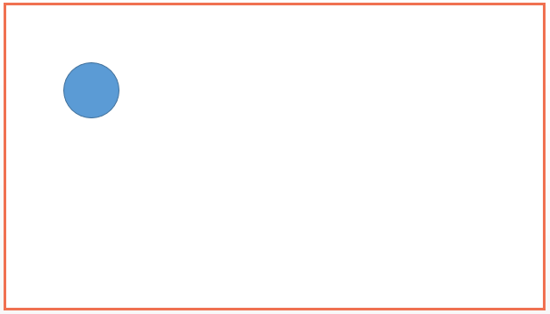

```python
pic('ppt0.png')
```

You'll have to try this out to see the result, but just FYI, this will open a new PowerPoint window and add a slide with a circle in it.

This opens up a lot of opportunities for slideware. Similarly, we can open an Excel application, add a circle, and change a few cells.

你看，运行之后就能看到结果：打开一个PPT，新建一页，然后在上面画一个圈儿。

这为幻灯片制作开启了新思路。当然，我们也可以打开一个Excel，在上面画一个圈儿，向单元格添加内容。

```python
# Open Excel
Application = win32com.client.Dispatch("Excel.Application")

# Show Excel. Unlike PPT, Word & Excel open up "hidden"
Application.Visible = 1

# Add a workbook
Workbook = Application.Workbooks.Add()

# Take the active sheet
Base = Workbook.ActiveSheet

# Add an oval. Shape 9 is an oval.
oval = Base.Shapes.AddShape(9, 100, 100, 100, 100)

# In the first row, add Values: 0.0, 0.5, 1.0
Base.Cells(1, 1).Value = 'Values'
Base.Cells(1, 2).Value = 0.0
Base.Cells(1, 3).Value = 0.5
Base.Cells(1, 4).Value = 1.0
```

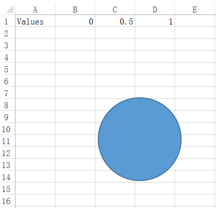

```python
pic('ppt1.png')
```

This means one can go about creating Excel models directly with Python.

看到了吧，可以直接通过python建立Excel。

# Picturing the IMDb Top 250

Let's begin by creating a slide that shows all of the [Top 250 movies](http://www.imdb.com/chart/top) on the IMDb.

First, let's load all the movies.

# 画图——IMDb Top 250

让我们做点儿更好玩儿的，用PPT显示IMDb的[Top 250 电影](http://www.imdb.com/chart/top)。

```python
from lxml.html import parse

tree = parse('http://www.imdb.com/chart/top')
movies = tree.findall('.//table[@class="chart"]//td[@class="titleColumn"]//a')
movies[0].text_content()
```

```
'The Shawshank Redemption'
```

We can show these movies. But before that, we can't remember these numbers for the shapes (like 9 is for circle). Let's pre-define those in line with how Office uses them and import them.

用[lxml](http://lxml.de/)可以轻松获取数据（[BeautifulSoup](http://www.crummy.com/software/BeautifulSoup/)也行）。但是，我们记不住形状对应数字（如9表示椭圆oval，5表示矩形rectangle），让我们先看看这些数字Office是如何用的。

```python
# 使用win32com里面的makepy -d生成MSO, MSPPT
import MSO, MSPPT
g = globals()
for c in dir(MSO.constants):    g[c] = getattr(MSO.constants, c)
for c in dir(MSPPT.constants):  g[c] = getattr(MSPPT.constants, c)
```

Let's draw each movie poster as a little box on a 25x10 grid. We don't have the images yet, but first, let's just draw the rectangles.

我们把每部电影的海报放到25列10行的栅格里，每个格子宽28高41。抓图片之前，我们先把格子都画好。

```python
Base = Presentation.Slides.Add(1, ppLayoutBlank)

width, height = 28, 41
for i, movie in enumerate(movies):
    # 25 columns one row, column step is 28
    x = 10 + width * (i % 25)
    # 10 rows one column, row step is 41
    y = 100 + height * (i // 25)
    r = Base.Shapes.AddShape(
            5, # Shape Rectangle
            x, y,
            width, height)
```

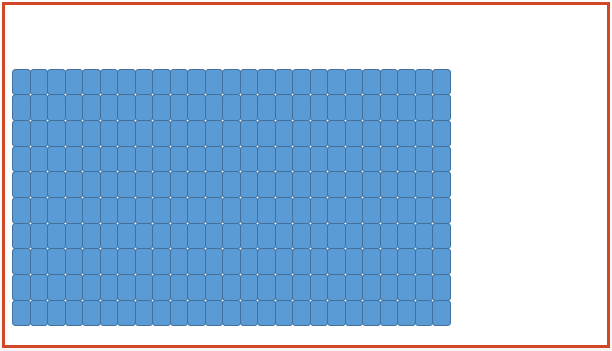

```python
pic('ppt2.png')
```

It would be nice to get posters into those, so let's scrape the posters.

海报放框里应该会好看点，下面我们抓海报。

```python
import os
from urlparse import urljoin
from urllib import urlretrieve
from hashlib import md5

# We'll keep the files under an img/ folder
if not os.path.exists('img'):
    os.makedirs('img')

def filename(movie):
    '''Filename = MD5 hash of its title in UTF8'''
    name = md5(movie.text_content().encode('utf8')).hexdigest()
    return os.path.join('img', name + '.jpg')

for movie in movies:
    if os.path.exists(filename(movie)):
        continue

    url = urljoin('http://www.imdb.com/', movie.get('href'))
    tree = parse(url)
    img = tree.find('.//td[@id="img_primary"]//img')
    urlretrieve(img.get('src'), filename(movie))
```

Now, instead of just rectangles, we'll use the posters.

现在，我们用这些海报来填充。

```python
Base = Presentation.Slides.Add(1, 12)

width, height = 28, 41
for i, movie in enumerate(movies):
    x = 10 + width * (i % 25)
    y = 100 + height * (i // 25)
    image = Base.Shapes.AddPicture(
        os.path.abspath(filename(movie)),
        LinkToFile=True,
        SaveWithDocument=False,
        Left=x, Top=y,
        Width=width, Height=height)
```

[figure not shown]

```python
pic('ppt3.png')
```

Wouldn't it be nice to have these hyperlinked to the movies?

要是海报能链接到每部电影就更帅了。

```python
Base = Presentation.Slides.Add(1, 12)

width, height = 28, 41
for i, movie in enumerate(movies):
    x = 10 + width * (i % 25)
    y = 100 + height * (i // 25)
    image = Base.Shapes.AddPicture(
        os.path.abspath(filename(movie)),
        LinkToFile=True,
        SaveWithDocument=False,
        Left=x, Top=y,
        Width=width, Height=height)
    url = urljoin('http://www.imdb.com/', movie.get('href'))
    link = image.ActionSettings(ppMouseClick).Hyperlink
    link.Address = url
    link.ScreenTip = movie.text_content().encode('cp1252')
```

This is ordered by rank, which is useful, but this makes it hard to locate a specific movie. What if we could sort this alphabetically?

But then, we don't want to lose the ordering by rank either. Could we, perhaps, get these movies to move on the click of a button to alphabetical or rank order?

Let's start by adding two buttons -- one to sort alphabetically and the ohter to sort by rank.

这是按照评分排序的，通常如此，但是很难定位到某一个电影。要是按字母排序呢？

但是，我们也不想丢失评分排序。那么，我们能不能加个按钮，让这些电影分别按字母/评分排序？

让我们加两个按钮吧——分别按字母/评分排序。

```python
Base = Presentation.Slides.Add(1, 12)

# Add two buttons: alphabetical and by rating
button_alpha = Base.Shapes.AddShape(5, 400, 10, 150, 40)
button_alpha.TextFrame.TextRange.Text = 'Alphabetical'

button_rating = Base.Shapes.AddShape(5, 560, 10, 150, 40)
button_rating.TextFrame.TextRange.Text = 'By rating'

# Get the index position when sorted alphabetically
movies_alpha = sorted(movies, key=lambda v: v.text_content())
index_alpha = dict((movie.text_content(), i) for i, movie in enumerate(movies_alpha))
```

We'll create a function that moves an image along a path when a trigger is clicked. This will be applied to each of the images.

我们建一个函数实现让按钮按下的时候，电影图片会沿着一个路径移动，然后将函数应用到每张图片。

```python
def animate(seq, image, trigger, path, duration=1.5):
    '''Move image along path when trigger is clicked'''
    effect = seq.AddEffect(
       Shape=image,
       effectId=msoAnimEffectPathDown,
       trigger=msoAnimTriggerOnShapeClick,
    )
    ani = effect.Behaviors.Add(msoAnimTypeMotion)
    ani.MotionEffect.Path = path
    effect.Timing.TriggerType = msoAnimTriggerWithPrevious
    effect.Timing.TriggerShape = trigger
    effect.Timing.Duration = duration
```

Finally, we draw all the images. After drawing them, we specify one animation for alphabetical ordering, and another for ordering by rating.

最后，我们将函数应用到所有图片上。之后，我们指定一个动画为按字母排序，另一个动画为按评分排序。

```python
seq_alpha = Base.TimeLine.InteractiveSequences.Add()
seq_rating = Base.TimeLine.InteractiveSequences.Add()
width, height = 28, 41
for i, movie in enumerate(movies):
    x = 10 + width * (i % 25)
    y = 100 + height * (i // 25)
    image = Base.Shapes.AddPicture(
        os.path.abspath(filename(movie)),
        LinkToFile=True,
        SaveWithDocument=False,
        Left=x, Top=y,
        Width=width, Height=height)
    url = urljoin('http://www.imdb.com/', movie.get('href'))
    link = image.ActionSettings(ppMouseClick).Hyperlink
    link.Address = url
    link.ScreenTip = movie.text_content().encode('cp1252')

    # Alphabetical
    index = index_alpha[movie.text_content()]
    animate(seq_alpha, image, trigger=button_alpha, path='M0,0 L{:.3f},{:.3f}'.format(
        (10 + width * (index % 25) - x) / 720.,
        (100 + height * (index // 25) - y) / 540.,
    ))

    # By rating
    animate(seq_rating, image, trigger=button_rating, path='M{:.3f},{:.3f} L0,0'.format(
        (10 + width * (index % 25) - x) / 720.,
        (100 + height * (index // 25) - y) / 540.,
    ))
```

[figure not shown]

```python
pic('ppt4.png')
```

# [Simple Treemap](http://www.s-anand.net/blog/automating-powerpoint-with-python/)

Let’s do something that you’d have trouble doing manually in PowerPoint: a [Treemap](http://www.cs.umd.edu/hcil/treemap-history/). The [Guardian’s](http://www.guardian.co.uk/) [data store](http://www.guardian.co.uk/data-store) kindly makes available the [top 50 banks by assets](http://spreadsheets.google.com/pub?key=phNtm3LmDZEOoyu8eDzdSXw) that we’ll use for this example. Our target output is a simple Treemap visualisation.

# 简单的矩形树状结构图

我们再用PPT做一个费事的[Treemap](http://www.cs.umd.edu/hcil/treemap-history/)。我们将使用[Guardian’s](http://www.guardian.co.uk/) [data store](http://www.guardian.co.uk/data-store)里面的[top 50 banks by assets](http://spreadsheets.google.com/pub?key=phNtm3LmDZEOoyu8eDzdSXw)数据来做一个简单的[矩形树状结构图](http://zh.wikipedia.org/wiki/%E7%9F%A9%E5%BD%A2%E5%BC%8F%E6%A0%91%E7%8A%B6%E7%BB%93%E6%9E%84%E7%BB%98%E5%9B%BE%E6%B3%95)。

```python
Application = win32com.client.Dispatch("PowerPoint.Application")
Application.Visible = True
Presentation = Application.Presentations.Add()
Slide = Presentation.Slides.Add(1, ppLayoutBlank)
```

Now let’s import data from The Guardian. The spreadsheet is [Google Spreadsheets](http://spreadsheets.google.com/pub?key=phNtm3LmDZEOoyu8eDzdSXw) and we can get just the banks and assets as a CSV file by adding "&output=csv&range=B2:C51" (via [OUseful.Info](http://blog.ouseful.info/2009/03/10/using-many-eyes-wikified-to-visualise-guardian-data-store-data-on-google-docs/)).

现在我们导入数据Guardian. 数据在[Google Spreadsheets](http://spreadsheets.google.com/pub?key=phNtm3LmDZEOoyu8eDzdSXw)，我们可以通过在链接后面增加"&output=csv&range=B2:C51"获取数据 (参考 [OUseful.Info](http://blog.ouseful.info/2009/03/10/using-many-eyes-wikified-to-visualise-guardian-data-store-data-on-google-docs/)).

```python
import urllib2, csv
url = 'http://spreadsheets.google.com/pub?key=phNtm3LmDZEOoyu8eDzdSXw&output=csv&range=B2:C51'
reader = csv.reader(urllib2.urlopen(url))
data = list((int(size.replace(',','')), bank.decode('utf8')) for bank, size in reader)
```

I created a simple Treemap class based on the [squarified algorithm](http://www.win.tue.nl/~vanwijk/stm.pdf) — you can play with the [source code](http://www.s-anand.net/treemap.zip). This Treemap class can be fed the the data in the format we have, and a draw function. The draw function takes (x, y, width, height, data_item) as parameters, where data_item is a row in the data list that we pass to it.

我用[squarified algorithm](http://www.win.tue.nl/~vanwijk/stm.pdf)建了一个simple Treemap类，你可以在[源代码](http://www.s-anand.net/treemap.zip)看到。这个Treemap类可以把数据转换成指定的格式。

```python
class Treemap:
    def __init__(self, width, height, data, draw):
        '''Treemap(width, height, data, fn) '''
        self.x, self.y = 0.0, 0.0
        self.scale  = (float(width * height) / self.get(data, sum)) ** 0.5
        self.width  = float(width)  / self.scale
        self.height = float(height) / self.scale
        self.draw   = draw
        self.squarify(data, [], min(self.width, self.height))

    def get(self, data, fn): return fn((x[0] for x in data))

    def layoutrow(self, row):
        if self.width >= self.height:
            dx = self.get(row, sum) / self.height
            step = self.height / len(row)
            for i,v in enumerate(row): self.draw(self.scale * self.x, self.scale * (self.y + i * step), self.scale * dx, self.scale * step, v)
            self.x += dx
            self.width -= dx
        else:
            dy = self.get(row, sum) / self.width
            step = self.width / len(row)
            for i,v in enumerate(row): self.draw(self.scale * (self.x + i * step), self.scale * self.y, self.scale * step, self.scale * dy, v)
            self.y += dy
            self.height -= dy

    def aspect(self, row, w):
        s = self.get(row, sum)
        return max(w*w*self.get(row, max)/s/s, s*s/w/w/self.get(row, max))

    def squarify(self, children, row, w):
        if not children:
            if row: self.layoutrow(row)
            return
        c = children[0]
        if not row or self.aspect(row, w) > self.aspect(row + [c], w):
            self.squarify(children[1:], row + [c], w)
        else:
            self.layoutrow(row)
            self.squarify(children, [], min(self.height, self.width))
```

还包括一个画图函数。画图函数参数为(x, y, width, height, data_item)，其中data_item是输入数据。

```python
def draw(x, y, w, h, n):
    shape = Slide.Shapes.AddShape(msoShapeRectangle, x, y, w, h)
    shape.TextFrame.TextRange.Text = n[1] + ' (' + str(int(n[0]/1000 + 500)) + 'M)'
    shape.TextFrame.MarginLeft = shape.TextFrame.MarginRight = 0
    shape.TextFrame.TextRange.Font.Size = 12
Treemap(720, 540, data, draw)
```

```
<__main__.Treemap instance at 0x08BFF148>
```

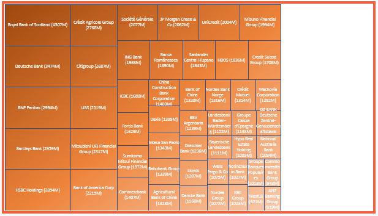

```python
pic('ppt5.png')
```

# Real-life examples

You can see how these were put to use at [Gramener](http://gramener.com/):

- [Vijay Karnataka's election coverage](http://gramener.com/vijaykarnataka/) was produced entirely in PowerPoint using Python. (And in Kannada, no less!)
- [Appstore downloads](http://gramener.com/appstore/appstore.pptx) -- a mini interactive application that shows the number of downloads from an app store, broken up by country, device, customer segment and time.
- [Revenue breakup](http://gramener.com/fmcg/fmcg-revenue-breakup.pptx) of an FMCG company as a clickable application

# 企业案例

你可以在[Gramener](http://gramener.com/)看到很多这样的东东:

- [Vijay Karnataka's election coverage](http://gramener.com/vijaykarnataka/)全是Python做的PPT（密集症慎入）。
- [Appstore downloads](http://gramener.com/appstore/appstore.pptx) -- 一个显示一个app store下载数量的交互应用，按照国家、设备、客户群和时间排序。
- [Revenue breakup](http://gramener.com/fmcg/fmcg-revenue-breakup.pptx) of an 快速消费品(FMCG,Fast Moving Consumer Goods)的应用。

# Live tweeting

Just for kicks, let's use PowerPoint as a dashboard to show live tweets.

I picked TwitterAPI to get streaming results, but twython and [Python Twitter Tools](https://github.com/sixohsix/twitter) look fine too.

# Live tweeting

让我们用PPT做一个dashboard来显示tweets信息。良好的网络环境是前提。

我用TwitterAPI来获取信息，twython和[Python Twitter Tools](https://github.com/sixohsix/twitter)当然也行。

```python
from TwitterAPI import TwitterAPI

# I'm keeping my keys and secrets in a secret file.
from secret_twitter import consumer_key, consumer_secret, access_token_key, access_token_secret
api = TwitterAPI(consumer_key, consumer_secret, access_token_key, access_token_secret)
```

This function will draw a tweet in a reasonably nice way on a slide. There's a block each for the profile picture, the text of the tweet, and the name of the user.

这个函数会让tweet在幻灯片中漂亮地呈现。包括配置图片，tweet内容，用户名。

```python
def draw_tweet(Base, item, pos):
    y = 40 + (pos % 4) * 120

    image = Base.Shapes.AddPicture(
        # To get the larger resolution image, just remove _normal from the URL
        item['user']['profile_image_url'].replace('_normal', ''),
        LinkToFile=True,
        SaveWithDocument=False,
        Left=20, Top=y,
        Width=100, Height=100)

    try:
        status = item['text'].encode('cp1252')
    except UnicodeEncodeError:
        status = item['text']
    text = Base.Shapes.AddShape(5, 130, y, 460, 100)
    text.Fill.ForeColor.ObjectThemeColor = msoThemeColorText1
    text.Fill.ForeColor.Brightness = +0.95
    text.Line.Visible = msoFalse
    text.TextFrame.TextRange.Text = status
    text.TextFrame.TextRange.Font.Color.ObjectThemeColor = msoThemeColorText1
    text.TextFrame.TextRange.ParagraphFormat.Alignment = ppAlignLeft

    user = Base.Shapes.AddShape(msoShapeRectangle, 600, y, 100, 100)
    user.Fill.ForeColor.ObjectThemeColor = msoThemeColorAccent6
    user.Line.Visible = False
    user.TextFrame.TextRange.Text = '@' + item['user']['screen_name']
```

让我们来看看跟踪的结果。

```python
Base = Presentation.Slides.Add(1, ppLayoutBlank)
api.request('statuses/filter', {'track': '1'})

for pos, item in enumerate(api.get_iterator()):
    draw_tweet(Base, item, pos)
    if pos > 10:
        break
```

**GAME OVER**